# Data Visualization IV

```python
import matplotlib.pyplot as plt
from mpl_toolkits.mplot3d import Axes3D as d3
import pandas as pd
import numpy as np
%matplotlib inline
car_data = pd.read_csv("Cars93.csv")

# Inline indicates to present graphs as cell output
# read_csv returns a DataFrame, the file path is relative to that of your notebook.
```

```python
print(car_data.columns)
car_data.tail()
```

```
Index(['Unnamed: 0', 'Manufacturer', 'Model', 'Type', 'Min.Price', 'Price',
       'Max.Price', 'MPG.city', 'MPG.highway', 'AirBags', 'DriveTrain',
       'Cylinders', 'EngineSize', 'Horsepower', 'RPM', 'Rev.per.mile',
       'Man.trans.avail', 'Fuel.tank.capacity', 'Passengers', 'Length',
       'Wheelbase', 'Width', 'Turn.circle', 'Rear.seat.room', 'Luggage.room',
       'Weight', 'Origin', 'Make'],
      dtype='object')
```

|  | Unnamed: 0 | Manufacturer | Model | Type | Min.Price | Price | Max.Price | MPG.city | MPG.highway | AirBags | ... | Passengers | Length | Wheelbase | Width | Turn.circle | Rear.seat.room | Luggage.room | Weight | Origin | Make |
| --- | --- | --- | --- | --- | --- | --- | --- | --- | --- | --- | --- | --- | --- | --- | --- | --- | --- | --- | --- | --- | --- |
| 88 | 89 | Volkswagen | Eurovan | Van | 16.6 | 19.7 | 22.7 | 17 | 21 | None | ... | 7 | 187 | 115 | 72 | 38 | 34.0 | NaN | 3960 | non-USA | Volkswagen Eurovan |
| 89 | 90 | Volkswagen | Passat | Compact | 17.6 | 20.0 | 22.4 | 21 | 30 | None | ... | 5 | 180 | 103 | 67 | 35 | 31.5 | 14.0 | 2985 | non-USA | Volkswagen Passat |
| 90 | 91 | Volkswagen | Corrado | Sporty | 22.9 | 23.3 | 23.7 | 18 | 25 | None | ... | 4 | 159 | 97 | 66 | 36 | 26.0 | 15.0 | 2810 | non-USA | Volkswagen Corrado |
| 91 | 92 | Volvo | 240 | Compact | 21.8 | 22.7 | 23.5 | 21 | 28 | Driver only | ... | 5 | 190 | 104 | 67 | 37 | 29.5 | 14.0 | 2985 | non-USA | Volvo 240 |
| 92 | 93 | Volvo | 850 | Midsize | 24.8 | 26.7 | 28.5 | 20 | 28 | Driver & Passenger | ... | 5 | 184 | 105 | 69 | 38 | 30.0 | 15.0 | 3245 | non-USA | Volvo 850 |

5 rows × 28 columns

#### we are bale to filter how many Manufacturers we have in the data by using the unique function belwo

```python
car_data['Manufacturer'].unique()
```

```
array(['Acura', 'Audi', 'BMW', 'Buick', 'Cadillac', 'Chevrolet',
       'Chrylser', 'Chrysler', 'Dodge', 'Eagle', 'Ford', 'Geo', 'Honda',
       'Hyundai', 'Infiniti', 'Lexus', 'Lincoln', 'Mazda',
       'Mercedes-Benz', 'Mercury', 'Mitsubishi', 'Nissan', 'Oldsmobile',
       'Plymouth', 'Pontiac', 'Saab', 'Saturn', 'Subaru', 'Suzuki',
       'Toyota', 'Volkswagen', 'Volvo'], dtype=object)
```

##### Using Group-by’s and Merges

Group-by’s can be used to build groups of rows based off a specific feature in your dataset eg. the ‘Manufacturer’ categorical column.

```python
group_by_Manufacturer = car_data.groupby(by=['Manufacturer'])
car_data_avg = round(group_by_Manufacturer.mean(),0)
print(type(car_data_avg))
group_by_Manufacturer.head(10)
```

```
<class 'pandas.core.frame.DataFrame'>
```

|  | Unnamed: 0 | Manufacturer | Model | Type | Min.Price | Price | Max.Price | MPG.city | MPG.highway | AirBags | ... | Passengers | Length | Wheelbase | Width | Turn.circle | Rear.seat.room | Luggage.room | Weight | Origin | Make |
| --- | --- | --- | --- | --- | --- | --- | --- | --- | --- | --- | --- | --- | --- | --- | --- | --- | --- | --- | --- | --- | --- |
| 0 | 1 | Acura | Integra | Small | 12.9 | 15.9 | 18.8 | 25 | 31 | None | ... | 5 | 177 | 102 | 68 | 37 | 26.5 | 11.0 | 2705 | non-USA | Acura Integra |
| 1 | 2 | Acura | Legend | Midsize | 29.2 | 33.9 | 38.7 | 18 | 25 | Driver & Passenger | ... | 5 | 195 | 115 | 71 | 38 | 30.0 | 15.0 | 3560 | non-USA | Acura Legend |
| 2 | 3 | Audi | 90 | Compact | 25.9 | 29.1 | 32.3 | 20 | 26 | Driver only | ... | 5 | 180 | 102 | 67 | 37 | 28.0 | 14.0 | 3375 | non-USA | Audi 90 |
| 3 | 4 | Audi | 100 | Midsize | 30.8 | 37.7 | 44.6 | 19 | 26 | Driver & Passenger | ... | 6 | 193 | 106 | 70 | 37 | 31.0 | 17.0 | 3405 | non-USA | Audi 100 |
| 4 | 5 | BMW | 535i | Midsize | 23.7 | 30.0 | 36.2 | 22 | 30 | Driver only | ... | 4 | 186 | 109 | 69 | 39 | 27.0 | 13.0 | 3640 | non-USA | BMW 535i |
| 5 | 6 | Buick | Century | Midsize | 14.2 | 15.7 | 17.3 | 22 | 31 | Driver only | ... | 6 | 189 | 105 | 69 | 41 | 28.0 | 16.0 | 2880 | USA | Buick Century |
| 6 | 7 | Buick | LeSabre | Large | 19.9 | 20.8 | 21.7 | 19 | 28 | Driver only | ... | 6 | 200 | 111 | 74 | 42 | 30.5 | 17.0 | 3470 | USA | Buick LeSabre |
| 7 | 8 | Buick | Roadmaster | Large | 22.6 | 23.7 | 24.9 | 16 | 25 | Driver only | ... | 6 | 216 | 116 | 78 | 45 | 30.5 | 21.0 | 4105 | USA | Buick Roadmaster |
| 8 | 9 | Buick | Riviera | Midsize | 26.3 | 26.3 | 26.3 | 19 | 27 | Driver only | ... | 5 | 198 | 108 | 73 | 41 | 26.5 | 14.0 | 3495 | USA | Buick Riviera |
| 9 | 10 | Cadillac | DeVille | Large | 33.0 | 34.7 | 36.3 | 16 | 25 | Driver only | ... | 6 | 206 | 114 | 73 | 43 | 35.0 | 18.0 | 3620 | USA | Cadillac DeVille |
| 10 | 11 | Cadillac | Seville | Midsize | 37.5 | 40.1 | 42.7 | 16 | 25 | Driver & Passenger | ... | 5 | 204 | 111 | 74 | 44 | 31.0 | 14.0 | 3935 | USA | Cadillac Seville |
| 11 | 12 | Chevrolet | Cavalier | Compact | 8.5 | 13.4 | 18.3 | 25 | 36 | None | ... | 5 | 182 | 101 | 66 | 38 | 25.0 | 13.0 | 2490 | USA | Chevrolet Cavalier |
| 12 | 13 | Chevrolet | Corsica | Compact | 11.4 | 11.4 | 11.4 | 25 | 34 | Driver only | ... | 5 | 184 | 103 | 68 | 39 | 26.0 | 14.0 | 2785 | USA | Chevrolet Corsica |
| 13 | 14 | Chevrolet | Camaro | Sporty | 13.4 | 15.1 | 16.8 | 19 | 28 | Driver & Passenger | ... | 4 | 193 | 101 | 74 | 43 | 25.0 | 13.0 | 3240 | USA | Chevrolet Camaro |
| 14 | 15 | Chevrolet | Lumina | Midsize | 13.4 | 15.9 | 18.4 | 21 | 29 | None | ... | 6 | 198 | 108 | 71 | 40 | 28.5 | 16.0 | 3195 | USA | Chevrolet Lumina |
| 15 | 16 | Chevrolet | Lumina_APV | Van | 14.7 | 16.3 | 18.0 | 18 | 23 | None | ... | 7 | 178 | 110 | 74 | 44 | 30.5 | NaN | 3715 | USA | Chevrolet Lumina_APV |
| 16 | 17 | Chevrolet | Astro | Van | 14.7 | 16.6 | 18.6 | 15 | 20 | None | ... | 8 | 194 | 111 | 78 | 42 | 33.5 | NaN | 4025 | USA | Chevrolet Astro |
| 17 | 18 | Chevrolet | Caprice | Large | 18.0 | 18.8 | 19.6 | 17 | 26 | Driver only | ... | 6 | 214 | 116 | 77 | 42 | 29.5 | 20.0 | 3910 | USA | Chevrolet Caprice |
| 18 | 19 | Chevrolet | Corvette | Sporty | 34.6 | 38.0 | 41.5 | 17 | 25 | Driver only | ... | 2 | 179 | 96 | 74 | 43 | NaN | NaN | 3380 | USA | Chevrolet Corvette |
| 19 | 20 | Chrylser | Concorde | Large | 18.4 | 18.4 | 18.4 | 20 | 28 | Driver & Passenger | ... | 6 | 203 | 113 | 74 | 40 | 31.0 | 15.0 | 3515 | USA | Chrylser Concorde |
| 20 | 21 | Chrysler | LeBaron | Compact | 14.5 | 15.8 | 17.1 | 23 | 28 | Driver & Passenger | ... | 6 | 183 | 104 | 68 | 41 | 30.5 | 14.0 | 3085 | USA | Chrysler LeBaron |
| 21 | 22 | Chrysler | Imperial | Large | 29.5 | 29.5 | 29.5 | 20 | 26 | Driver only | ... | 6 | 203 | 110 | 69 | 44 | 36.0 | 17.0 | 3570 | USA | Chrysler Imperial |
| 22 | 23 | Dodge | Colt | Small | 7.9 | 9.2 | 10.6 | 29 | 33 | None | ... | 5 | 174 | 98 | 66 | 32 | 26.5 | 11.0 | 2270 | USA | Dodge Colt |
| 23 | 24 | Dodge | Shadow | Small | 8.4 | 11.3 | 14.2 | 23 | 29 | Driver only | ... | 5 | 172 | 97 | 67 | 38 | 26.5 | 13.0 | 2670 | USA | Dodge Shadow |
| 24 | 25 | Dodge | Spirit | Compact | 11.9 | 13.3 | 14.7 | 22 | 27 | Driver only | ... | 6 | 181 | 104 | 68 | 39 | 30.5 | 14.0 | 2970 | USA | Dodge Spirit |
| 25 | 26 | Dodge | Caravan | Van | 13.6 | 19.0 | 24.4 | 17 | 21 | Driver only | ... | 7 | 175 | 112 | 72 | 42 | 26.5 | NaN | 3705 | USA | Dodge Caravan |
| 26 | 27 | Dodge | Dynasty | Midsize | 14.8 | 15.6 | 16.4 | 21 | 27 | Driver only | ... | 6 | 192 | 105 | 69 | 42 | 30.5 | 16.0 | 3080 | USA | Dodge Dynasty |
| 27 | 28 | Dodge | Stealth | Sporty | 18.5 | 25.8 | 33.1 | 18 | 24 | Driver only | ... | 4 | 180 | 97 | 72 | 40 | 20.0 | 11.0 | 3805 | USA | Dodge Stealth |
| 28 | 29 | Eagle | Summit | Small | 7.9 | 12.2 | 16.5 | 29 | 33 | None | ... | 5 | 174 | 98 | 66 | 36 | 26.5 | 11.0 | 2295 | USA | Eagle Summit |
| 29 | 30 | Eagle | Vision | Large | 17.5 | 19.3 | 21.2 | 20 | 28 | Driver & Passenger | ... | 6 | 202 | 113 | 74 | 40 | 30.0 | 15.0 | 3490 | USA | Eagle Vision |
| ... | ... | ... | ... | ... | ... | ... | ... | ... | ... | ... | ... | ... | ... | ... | ... | ... | ... | ... | ... | ... | ... |
| 63 | 64 | Nissan | Sentra | Small | 8.7 | 11.8 | 14.9 | 29 | 33 | Driver only | ... | 5 | 170 | 96 | 66 | 33 | 26.0 | 12.0 | 2545 | non-USA | Nissan Sentra |
| 64 | 65 | Nissan | Altima | Compact | 13.0 | 15.7 | 18.3 | 24 | 30 | Driver only | ... | 5 | 181 | 103 | 67 | 40 | 28.5 | 14.0 | 3050 | non-USA | Nissan Altima |
| 65 | 66 | Nissan | Quest | Van | 16.7 | 19.1 | 21.5 | 17 | 23 | None | ... | 7 | 190 | 112 | 74 | 41 | 27.0 | NaN | 4100 | non-USA | Nissan Quest |
| 66 | 67 | Nissan | Maxima | Midsize | 21.0 | 21.5 | 22.0 | 21 | 26 | Driver only | ... | 5 | 188 | 104 | 69 | 41 | 28.5 | 14.0 | 3200 | non-USA | Nissan Maxima |
| 67 | 68 | Oldsmobile | Achieva | Compact | 13.0 | 13.5 | 14.0 | 24 | 31 | None | ... | 5 | 188 | 103 | 67 | 39 | 28.0 | 14.0 | 2910 | USA | Oldsmobile Achieva |
| 68 | 69 | Oldsmobile | Cutlass_Ciera | Midsize | 14.2 | 16.3 | 18.4 | 23 | 31 | Driver only | ... | 5 | 190 | 105 | 70 | 42 | 28.0 | 16.0 | 2890 | USA | Oldsmobile Cutlass_Ciera |
| 69 | 70 | Oldsmobile | Silhouette | Van | 19.5 | 19.5 | 19.5 | 18 | 23 | None | ... | 7 | 194 | 110 | 74 | 44 | 30.5 | NaN | 3715 | USA | Oldsmobile Silhouette |
| 70 | 71 | Oldsmobile | Eighty-Eight | Large | 19.5 | 20.7 | 21.9 | 19 | 28 | Driver only | ... | 6 | 201 | 111 | 74 | 42 | 31.5 | 17.0 | 3470 | USA | Oldsmobile Eighty-Eight |
| 71 | 72 | Plymouth | Laser | Sporty | 11.4 | 14.4 | 17.4 | 23 | 30 | None | ... | 4 | 173 | 97 | 67 | 39 | 24.5 | 8.0 | 2640 | USA | Plymouth Laser |
| 72 | 73 | Pontiac | LeMans | Small | 8.2 | 9.0 | 9.9 | 31 | 41 | None | ... | 4 | 177 | 99 | 66 | 35 | 25.5 | 17.0 | 2350 | USA | Pontiac LeMans |
| 73 | 74 | Pontiac | Sunbird | Compact | 9.4 | 11.1 | 12.8 | 23 | 31 | None | ... | 5 | 181 | 101 | 66 | 39 | 25.0 | 13.0 | 2575 | USA | Pontiac Sunbird |
| 74 | 75 | Pontiac | Firebird | Sporty | 14.0 | 17.7 | 21.4 | 19 | 28 | Driver & Passenger | ... | 4 | 196 | 101 | 75 | 43 | 25.0 | 13.0 | 3240 | USA | Pontiac Firebird |
| 75 | 76 | Pontiac | Grand_Prix | Midsize | 15.4 | 18.5 | 21.6 | 19 | 27 | None | ... | 5 | 195 | 108 | 72 | 41 | 28.5 | 16.0 | 3450 | USA | Pontiac Grand_Prix |
| 76 | 77 | Pontiac | Bonneville | Large | 19.4 | 24.4 | 29.4 | 19 | 28 | Driver & Passenger | ... | 6 | 177 | 111 | 74 | 43 | 30.5 | 18.0 | 3495 | USA | Pontiac Bonneville |
| 77 | 78 | Saab | 900 | Compact | 20.3 | 28.7 | 37.1 | 20 | 26 | Driver only | ... | 5 | 184 | 99 | 67 | 37 | 26.5 | 14.0 | 2775 | non-USA | Saab 900 |
| 78 | 79 | Saturn | SL | Small | 9.2 | 11.1 | 12.9 | 28 | 38 | Driver only | ... | 5 | 176 | 102 | 68 | 40 | 26.5 | 12.0 | 2495 | USA | Saturn SL |
| 79 | 80 | Subaru | Justy | Small | 7.3 | 8.4 | 9.5 | 33 | 37 | None | ... | 4 | 146 | 90 | 60 | 32 | 23.5 | 10.0 | 2045 | non-USA | Subaru Justy |
| 80 | 81 | Subaru | Loyale | Small | 10.5 | 10.9 | 11.3 | 25 | 30 | None | ... | 5 | 175 | 97 | 65 | 35 | 27.5 | 15.0 | 2490 | non-USA | Subaru Loyale |
| 81 | 82 | Subaru | Legacy | Compact | 16.3 | 19.5 | 22.7 | 23 | 30 | Driver only | ... | 5 | 179 | 102 | 67 | 37 | 27.0 | 14.0 | 3085 | non-USA | Subaru Legacy |
| 82 | 83 | Suzuki | Swift | Small | 7.3 | 8.6 | 10.0 | 39 | 43 | None | ... | 4 | 161 | 93 | 63 | 34 | 27.5 | 10.0 | 1965 | non-USA | Suzuki Swift |
| 83 | 84 | Toyota | Tercel | Small | 7.8 | 9.8 | 11.8 | 32 | 37 | Driver only | ... | 5 | 162 | 94 | 65 | 36 | 24.0 | 11.0 | 2055 | non-USA | Toyota Tercel |
| 84 | 85 | Toyota | Celica | Sporty | 14.2 | 18.4 | 22.6 | 25 | 32 | Driver only | ... | 4 | 174 | 99 | 69 | 39 | 23.0 | 13.0 | 2950 | non-USA | Toyota Celica |
| 85 | 86 | Toyota | Camry | Midsize | 15.2 | 18.2 | 21.2 | 22 | 29 | Driver only | ... | 5 | 188 | 103 | 70 | 38 | 28.5 | 15.0 | 3030 | non-USA | Toyota Camry |
| 86 | 87 | Toyota | Previa | Van | 18.9 | 22.7 | 26.6 | 18 | 22 | Driver only | ... | 7 | 187 | 113 | 71 | 41 | 35.0 | NaN | 3785 | non-USA | Toyota Previa |
| 87 | 88 | Volkswagen | Fox | Small | 8.7 | 9.1 | 9.5 | 25 | 33 | None | ... | 4 | 163 | 93 | 63 | 34 | 26.0 | 10.0 | 2240 | non-USA | Volkswagen Fox |
| 88 | 89 | Volkswagen | Eurovan | Van | 16.6 | 19.7 | 22.7 | 17 | 21 | None | ... | 7 | 187 | 115 | 72 | 38 | 34.0 | NaN | 3960 | non-USA | Volkswagen Eurovan |
| 89 | 90 | Volkswagen | Passat | Compact | 17.6 | 20.0 | 22.4 | 21 | 30 | None | ... | 5 | 180 | 103 | 67 | 35 | 31.5 | 14.0 | 2985 | non-USA | Volkswagen Passat |
| 90 | 91 | Volkswagen | Corrado | Sporty | 22.9 | 23.3 | 23.7 | 18 | 25 | None | ... | 4 | 159 | 97 | 66 | 36 | 26.0 | 15.0 | 2810 | non-USA | Volkswagen Corrado |
| 91 | 92 | Volvo | 240 | Compact | 21.8 | 22.7 | 23.5 | 21 | 28 | Driver only | ... | 5 | 190 | 104 | 67 | 37 | 29.5 | 14.0 | 2985 | non-USA | Volvo 240 |
| 92 | 93 | Volvo | 850 | Midsize | 24.8 | 26.7 | 28.5 | 20 | 28 | Driver & Passenger | ... | 5 | 184 | 105 | 69 | 38 | 30.0 | 15.0 | 3245 | non-USA | Volvo 850 |

93 rows × 28 columns

# With the generated dataset above we are able to do better visualizations for the data set

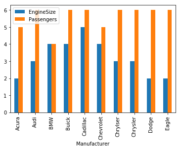

```python
# Since all the columns in car_data_count are the same, we will use just the first column as the rest yield the same result. iloc allows us to take all the rows and the zeroth column.

car_data_count_series = car_data_avg.iloc[5:5,1]


## we will assemble a DataFrame of only the relevant features to plot
features_of_interest = pd.DataFrame({'EngineSize': car_data_avg['EngineSize'],
                                     'Passengers': car_data_avg['Passengers'],
                                   }
                                   )

## Let us plot a few of the manufactures for visibility
features_of_interest = features_of_interest.iloc[:10,]
features_of_interest.plot(kind='bar')
```

#### Stacked bar graph

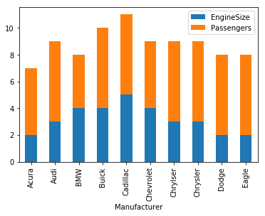

```python
features_of_interest.plot.bar(stacked=True)
```

```python
#### Hosrizontal bar graph
```

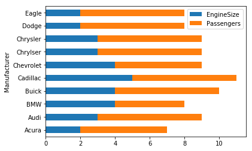

```python
features_of_interest.plot.barh(stacked=True)
```

#### Want to try pie charts? Lets do it

##### Lets prepare some data. We can create a pie chart to show the population of categorical variables

```python
# group by passengers
group_by_Passengers = car_data.groupby(by=['Type'])

car_typePassengers = group_by_Passengers.count()

# get first column
car_typePassengers = pd.DataFrame(car_typecount.iloc[:,0])

car_typePassengers.rename(columns={'Manufacturer': 'Passengers'}, inplace=True)

car_typePassengers.plot.pie(subplots=True,figsize=(8, 8))

car_typePassenger.head
```

[output not shown]

[output not shown]

```
         Unnamed: 0
Type
Compact          16
Large            11
Midsize          22
Small            21
Sporty           14
Van               9
```

```
array([<matplotlib.axes._subplots.AxesSubplot object at 0x0000015C57D80240>],
      dtype=object)
```

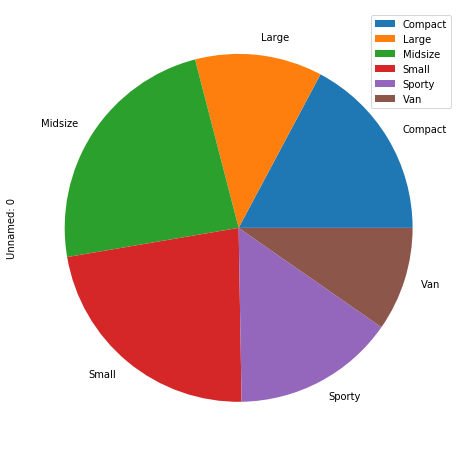

```python
# group by Type
group_by_Type = car_data.groupby(by=['Type'])

car_typecount = group_by_Type.count()

car_typecount = pd.DataFrame(car_typecount.iloc[:,0])
print(pd.DataFrame(car_typecount.iloc[:,0]))
car_typecount.rename(columns={'Manufacturer': 'Type'}, inplace=True)

car_typecount.plot.pie(subplots=True,figsize=(8, 8))
```

```
array([<matplotlib.axes._subplots.AxesSubplot object at 0x0000015C58171D68>],
      dtype=object)
```

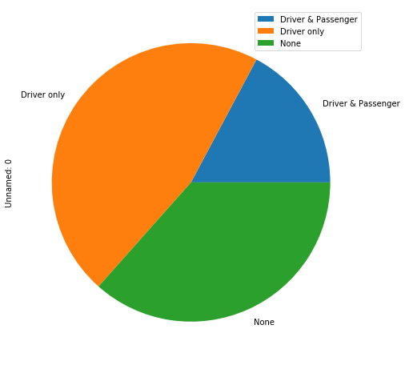

```python
# Group by Airbags
group_by_AirBags = car_data.groupby(by=['AirBags'])

car_AirBagscount = group_by_AirBags.count()

car_AirBagscount = pd.DataFrame(car_AirBagscount.iloc[:,0])

car_AirBagscount.rename(columns={'Manufacturer': 'Airbags'}, inplace=True)


car_AirBagscount.plot.pie(subplots=True, figsize=(8, 8))
```

# COMPULSORY TASK

THIS AREA PLOT BELOW SHOWS THAT THERE IS A LINK BETWEEN THE SIZE OF THE ENGINE AND THE PASSENGERS BUT THERE IS SOME EXCEPTIONS LIKE THAT OF BMW, BUICK AND CHRYSLER. THIS CAN REASE SOME GOOD WHYs QUESTIONS

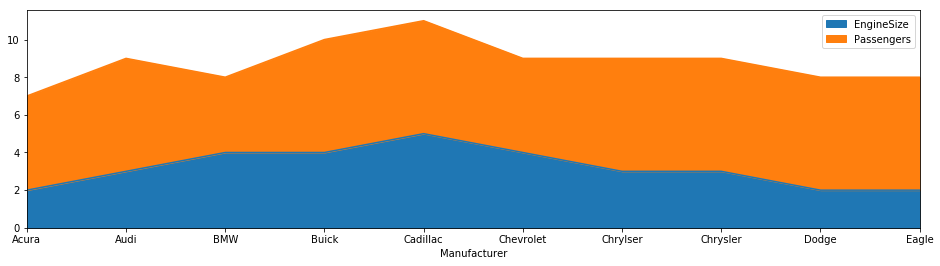

```python
features_of_interest.plot(kind='area', figsize=(16,4))
plt.show()
```

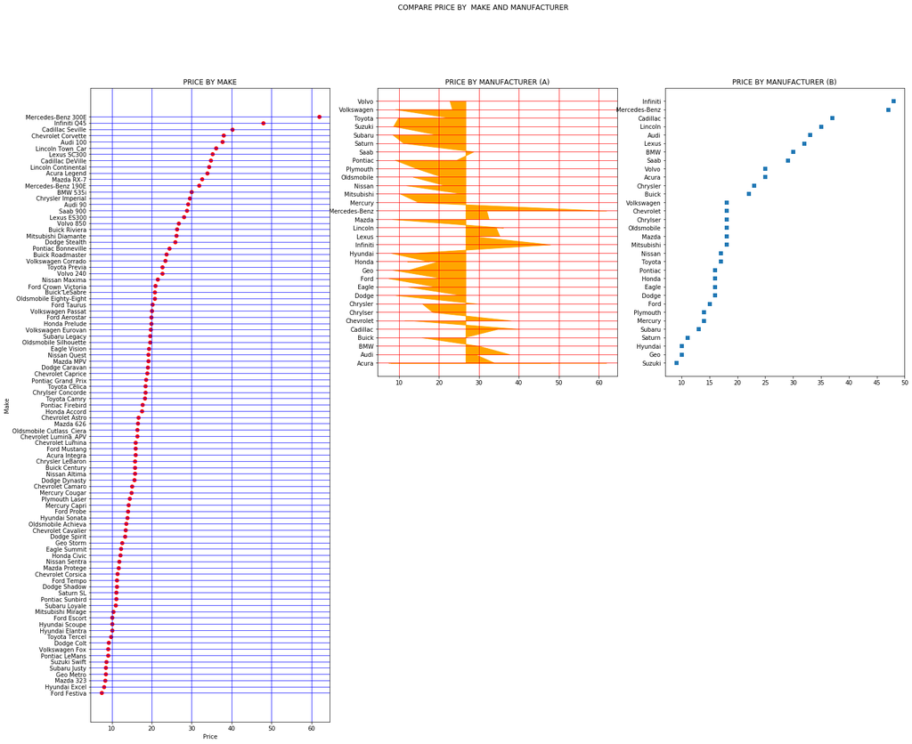

```python
#we know that we can extract data from our df car_data so we get the price at index 5 and the manufacturer by string
#these are the only variables we gonna need
car_by_price = car_data.sort_values(by='Price')
price_sort = car_by_price.iloc[:,5]
price = car_data.iloc[:,5]
make = car_by_price['Make']
man  = car_data['Manufacturer']

k = car_data_avg.reset_index(['Manufacturer']).sort_values(by='Price')
man_avg = k['Manufacturer']

price_avg = k['Price']

#due to the large amount of data and the difering axis length i need to be able to controle the size of my figure
plt.figure(figsize=(25,20))
plt.suptitle("COMPARE PRICE BY  MAKE AND MANUFACTURER ")


plt.subplot(131)
plt.scatter(price_sort, make, color='r')
plt.xlabel("Price")
plt.ylabel('Make')
plt.title('PRICE BY MAKE')
plt.grid(True, color='b')     #  i think the grid makes the plot a lot more readable

plt.subplot(232)

plt.fill_between(price, man, color='orange')
plt.grid(True, color='r')
plt.title('PRICE BY MANUFACTURER (A)')

plt.subplot(233)
plt.scatter(price_avg, man_avg, marker='s')
plt.title("PRICE BY MANUFACTURER (B)")

plt.show()
```

AND WE GONNA TRY TO FIGURE OUT THE SIZES OF CARS AND GROUP THEM BY TYPE.(THAT SOUND LIKE A GOOD STORY TO TELL)

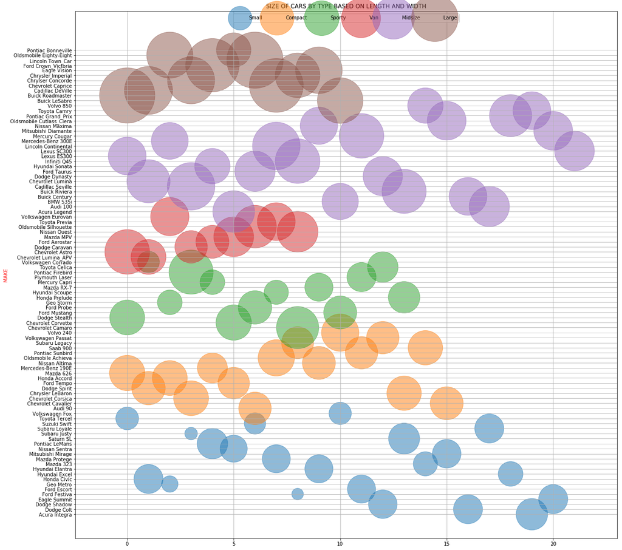

```python
import random   # start by importing the random module because we want the location of the cars to random on the plot
                # but how we gonna know the size? well let's see if the picture can tell the story.


# on this section we collecting variables that we need for our story

small = car_data.loc[car_data['Type'] == 'Small', ['Length', 'Width', 'Make']]

large = car_data.loc[car_data['Type'] == 'Large', ['Length', 'Width', 'Make']]

sporty = car_data.loc[car_data['Type'] == 'Sporty', ['Length', 'Width', 'Make']]

van = car_data.loc[car_data['Type'] == 'Van', ['Length', 'Width', 'Make']]

midsize = car_data.loc[car_data['Type'] == 'Midsize', ['Length', 'Width', 'Make']]

compact = car_data.loc[car_data['Type'] == 'Compact', ['Length', 'Width', 'Make']]



# and over here we creating some random numbers for the x_axis

v=list(range(0,len(van['Make'])))
random.shuffle(v)

sa=list(range(0,len(small['Make'])))
random.shuffle(sa)

l=list(range(0,len(large['Make'])))
random.shuffle(l)
                                                            # so what is actually happening here is: because need the x_axis to match
                                                            # the y_axis we use the length of our data(s) and create the x_axis but randomly
                                                            # does that make sense?  if not just check the plot and see if the data is unable to tell the story despite their random position
c=list(range(0,len(compact['Make'])))
random.shuffle(c)

m=list(range(0,len(midsize['Make'])))
random.shuffle(m)

sp=list(range(0,len(sporty['Make'])))
random.shuffle(sp)


# so we gonna just have 1 column and 1 row but we just gonna make our figure a little bit bigger to fit our  data
plt.figure(figsize=(20,20)) #i think 20*20 is fine for my screen but feel free to change the size if it doesn't fit your screen


#now let's see what is happening in our scatter plot... (by the way if you did not think we were going to use scatter again! well you just find out.)
#the only thing that looks dodgy in this plot is the s=argument or size. well I can explain;
#remember the crazy idea of shuffing the x_axis and see how the data is gonna tell its story, well, the secret lies in the size of
#the dot which turns out to a BUBBLE therefore giving me a an excuse of using the scatter plot again because in this case we can call it a BUBBLE chart

plt.scatter(sa, small['Make'], s=(small[['Length','Width']].sum(axis=1)-180)**2, alpha=.5,label='Small')

plt.scatter(c, compact['Make'], s=(compact[['Length','Width']].sum(axis=1)-180)**2, alpha=.5, label='Compact')

plt.scatter(sp, sporty['Make'], s=(sporty[['Length','Width']].sum(axis=1)-180)**2, alpha=.5, label= 'Sporty')

plt.scatter(v, van['Make'], s=(van[['Length','Width']].sum(axis=1)-180)**2, alpha=.5, label="Van")

plt.scatter(m, midsize['Make'], s=(midsize[['Length','Width']].sum(axis=1)-180)**2, alpha=.5, label='Midsize')

plt.scatter(l, large['Make'], s=(large[['Length','Width']].sum(axis=1)-180)**2, alpha=.5, label='Large')




plt.ylabel('MAKE', color='r')

plt.title('SIZE OF CARS BY TYPE BASED ON LENGTH AND WIDTH')

plt.legend(loc=9,  ncol=6)

plt.grid(True)
```

```python
plt.figure(figsize=(20,20))
#plt.hist(car_data['Manufacturer'])
plt.show()
car_data['Manufacturer'].head()
```

```
0    Acura
1    Acura
2     Audi
3     Audi
4      BMW
Name: Manufacturer, dtype: object
```

BELOW IS A SIMPLE BUBLE SHART THAT SHOWS THE smallest BUBLE AS THE CHEAPEST SAFE CAR TO THE biggest BUBBLE AS THE MOST EXPENSIVE SAFE CAR IN THE MARKET. (of course there is other things or variables that can be used to determine the safey of a car but for now we gonna stick to airbags fact),

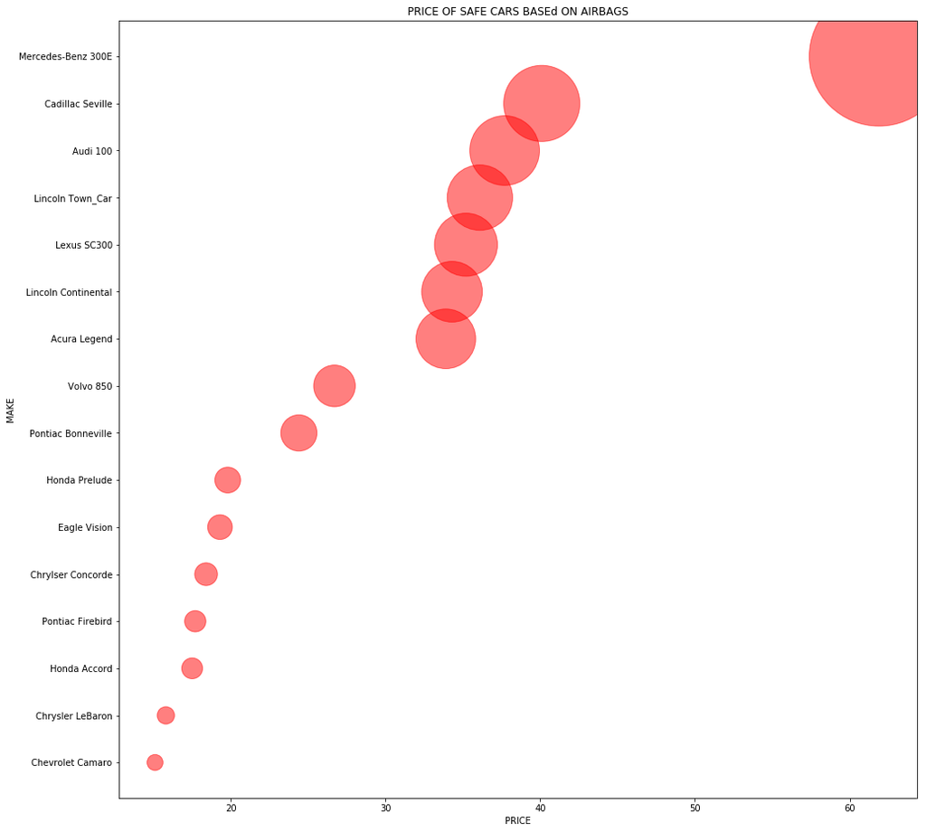

```python
#I'm sorry I can't help it. i have to use scatter again

#we start off by collecting the necessary data,  we know we have a car by price variable somewhere up-there.
#so we just use that and  locate all the cars that have hair bags for the driver and the passenger then from there we get the price and the make
safe_cars = car_by_price.loc[car_by_price['AirBags']== 'Driver & Passenger']
price_safe_car = safe_cars['Price']
make_safe_car = safe_cars['Make']
#over here we set the size of our working area so that our data can fit in
plt.figure(figsize=(16,16))

#then we set the size of the marker so represent it car by price
plt.scatter(price_safe_car, make_safe_car ,marker='o', s=(price_safe_car-(price_safe_car.min()-10))**2.5, c='r', alpha=.5)
plt.ylabel('MAKE')
plt.xlabel('PRICE')
plt.title('PRICE OF SAFE CARS BASEd ON AIRBAGS')
```

```python
#plt.hist(group_by_Manufacturer['Make'])
car_data.head()
```

|  | Unnamed: 0 | Manufacturer | Model | Type | Min.Price | Price | Max.Price | MPG.city | MPG.highway | AirBags | ... | Passengers | Length | Wheelbase | Width | Turn.circle | Rear.seat.room | Luggage.room | Weight | Origin | Make |
| --- | --- | --- | --- | --- | --- | --- | --- | --- | --- | --- | --- | --- | --- | --- | --- | --- | --- | --- | --- | --- | --- |
| 0 | 1 | Acura | Integra | Small | 12.9 | 15.9 | 18.8 | 25 | 31 | None | ... | 5 | 177 | 102 | 68 | 37 | 26.5 | 11.0 | 2705 | non-USA | Acura Integra |
| 1 | 2 | Acura | Legend | Midsize | 29.2 | 33.9 | 38.7 | 18 | 25 | Driver & Passenger | ... | 5 | 195 | 115 | 71 | 38 | 30.0 | 15.0 | 3560 | non-USA | Acura Legend |
| 2 | 3 | Audi | 90 | Compact | 25.9 | 29.1 | 32.3 | 20 | 26 | Driver only | ... | 5 | 180 | 102 | 67 | 37 | 28.0 | 14.0 | 3375 | non-USA | Audi 90 |
| 3 | 4 | Audi | 100 | Midsize | 30.8 | 37.7 | 44.6 | 19 | 26 | Driver & Passenger | ... | 6 | 193 | 106 | 70 | 37 | 31.0 | 17.0 | 3405 | non-USA | Audi 100 |
| 4 | 5 | BMW | 535i | Midsize | 23.7 | 30.0 | 36.2 | 22 | 30 | Driver only | ... | 4 | 186 | 109 | 69 | 39 | 27.0 | 13.0 | 3640 | non-USA | BMW 535i |

5 rows × 28 columns

```python
car_data.columns
```

```
Index(['Unnamed: 0', 'Manufacturer', 'Model', 'Type', 'Min.Price', 'Price',
       'Max.Price', 'MPG.city', 'MPG.highway', 'AirBags', 'DriveTrain',
       'Cylinders', 'EngineSize', 'Horsepower', 'RPM', 'Rev.per.mile',
       'Man.trans.avail', 'Fuel.tank.capacity', 'Passengers', 'Length',
       'Wheelbase', 'Width', 'Turn.circle', 'Rear.seat.room', 'Luggage.room',
       'Weight', 'Origin', 'Make'],
      dtype='object')
```

```python
car_data['Luggage.room'].describe()
```

```
count    82.000000
mean     13.890244
std       2.997967
min       6.000000
25%      12.000000
50%      14.000000
75%      15.000000
max      22.000000
Name: Luggage.room, dtype: float64
```

```python
#base on the description above, we can take the Luggage.room and caterize it into four categories
#andd create a new column for those categories and maybe name it Luggage group

car_data['Luggage group'] = pd.cut(car_data['Luggage.room'], [5, 10, 14, 18, 22], labels=['6-10', '10-14', '14-18', '18-22'] )

lu_group = car_data.groupby(['Luggage group'])['Make'].value_counts()
lu_group.head(20)
```

```
Luggage group  Make
6-10           Geo Metro             1
               Honda Prelude         1
               Hyundai Scoupe        1
               Lexus SC300           1
               Mercury Capri         1
               Plymouth Laser        1
               Subaru Justy          1
               Suzuki Swift          1
               Volkswagen Fox        1
10-14          Acura Integra         1
               Audi 90               1
               BMW 535i              1
               Buick Riviera         1
               Cadillac Seville      1
               Chevrolet Camaro      1
               Chevrolet Cavalier    1
               Chevrolet Corsica     1
               Chrysler LeBaron      1
               Dodge Colt            1
               Dodge Shadow          1
Name: Make, dtype: int64
```

```python
car_data['Luggage group'].value_counts()
```

```
10-14    43
14-18    25
6-10      9
18-22     5
Name: Luggage group, dtype: int64
```

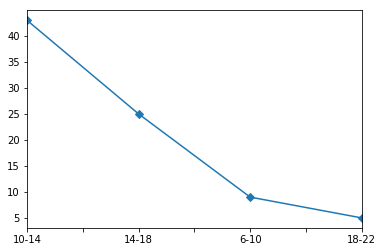

```python
car_data['Luggage group'].value_counts().plot(marker='D')#then show from the most famous to the least
```

```python
#we can also check the origin difference between USA and non USA


#to accomplish that we are going to create a new data from our original df
origin =pd.DataFrame(car_data.Origin.value_counts())

#set the index name and rename the other column and then reset the Index
origin.index.name = 'Origin'
origin.rename(index=str, columns={'Origin': 'Total'}, inplace=True)
origin.reset_index(inplace=True)

origin
```

|  | Origin | Total |
| --- | --- | --- |
| 0 | USA | 48 |
| 1 | non-USA | 45 |

```
<BarContainer object of 2 artists>
```

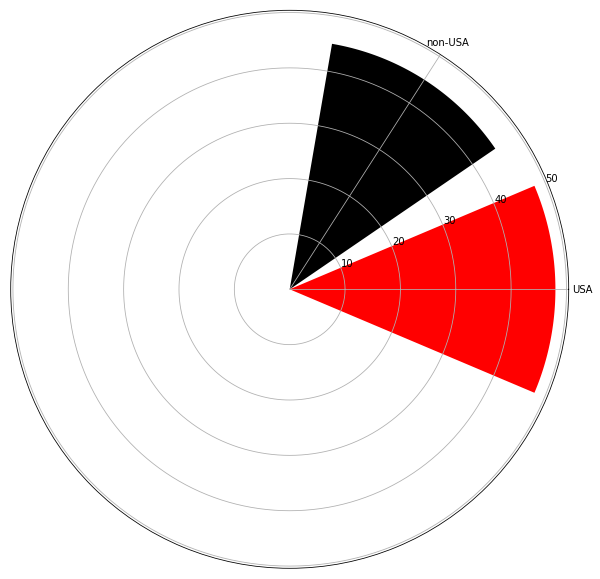

```python
fig = plt.figure(figsize=(10,18))
ax = fig.add_subplot(111, projection= 'polar')

ax.bar(origin.Origin, origin.Total, color=('r', 'k'))
```

```python
car_data.info
```

[output not shown]

[output cut: 238 more lines]